# EkonometriaElizaTworkowska

### Wykresy dla obwodu talii

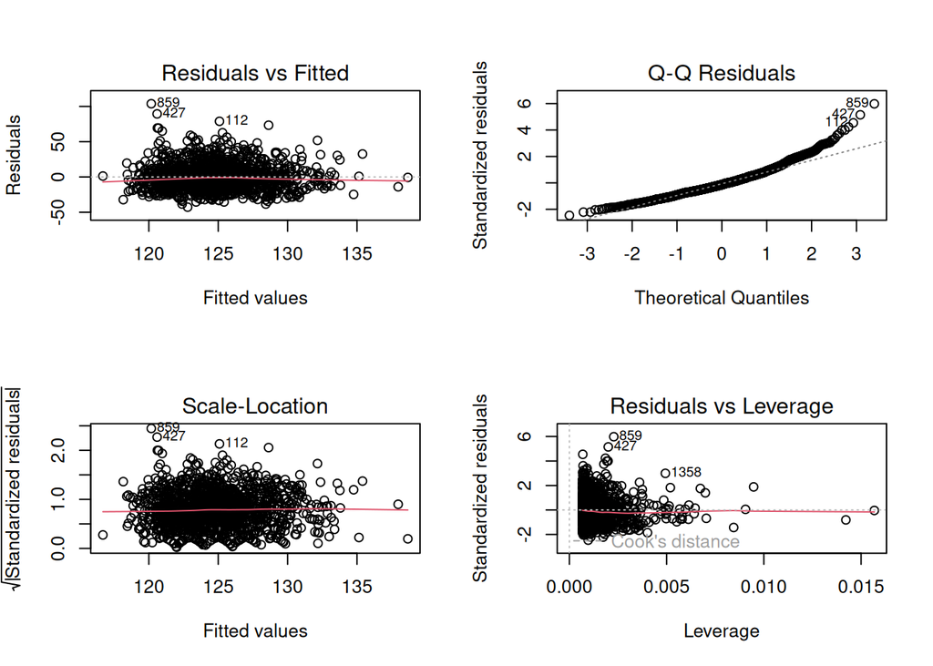

```r
par(mfrow = c(2,2))

plot(lm_waist)
```

**1. Reszty vs Wartości dopasowane:** wykres sprawdza liniowość związku i stałą wariancję reszt. U nas punkty nie tworzą wzoru (brak np. krzywej lub lejku) - sugeruje to liniowość i homoskedatyczność modelu.

**2. Wykres kwantyl** - kwantyl: Werifukuje normalność rozkładu reszt. Punkty leżą głównie wzdłuż lini referencyjnej, oprócz widocznego odstępu przy wyższych wartościach, które mogą zaburzać nam model.

**4. Reszty vs Wpływ obserwacji:** Identyfikuje obserwacje wpływowe (outliers, high-leverage points). Na naszym wykresie linia Cooka jest praktycznie niewidoczna - wskazuje na brak outlierów.

## Test modeli

Zrobimy testy modeli `(systolic~age)` i `(systolic~waist)`. Za pomocą biblotek `lmtest, broom` wyświetlimy wyniki w formie tabeli. Jeżeli spełnią wymagania interpretacji testów poprawnych (p.value > 0.05) to wyświetlimy ‘OK’.

```r
library(lmtest)
library(broom)

# Funkcja do ekstrakcji wyników testów
get_test_results <- function(model) {
  # Durbin-Watson
  dw <- dwtest(model)
  # Breusch-Pagan
  bp <- bptest(model)
  # Shapiro-Wilk
  sw <- shapiro.test(resid(model))
  # RESET
  reset <- resettest(model)

  data.frame(
    Test = c("Durbin-Watson (autokorelacja)",
             "Breusch-Pagan (homoskedastyczność)",
             "Shapiro-Wilk (normalność)",
             "RESET (liniowość)"),
    Statystyka = c(dw$statistic, bp$statistic, sw$statistic, reset$statistic),
    p_value = c(dw$p.value, bp$p.value, sw$p.value, reset$p.value)
  )
}

# Tabela porównawcza
results_age <- get_test_results(lm_age)
results_waist <- get_test_results(lm_waist)

comparison_table <- data.frame(
  Test = results_age$Test,
  lm_SO_Stat = round(results_age$Statystyka, 3),
  lm_SO_p = round(results_age$p_value, 4),
  lm_SO_log_Stat = round(results_waist$Statystyka, 3),
  lm_SO_log_p = round(results_waist$p_value, 4)
)

colnames(comparison_table) <- c("Test",
                                "Stat. (Age)", "p-value (Age)",
                                "Stat. (Waist)", "p-value (Waist)")

# Dodajemy znaczenie gwiazdkowe
comparison_table <- comparison_table %>%
  mutate(
    `Wniosek (Age)` = ifelse(`p-value (Age)` < 0.05, "Problem***", "OK"),
    `Wniosek (Waist)` = ifelse(`p-value (Waist)` < 0.05, "Problem***", "OK")
  )

knitr::kable(comparison_table, align = "c", caption = "Porównanie diagnostyki modeli")
```

Porównanie diagnostyki modeli

| Test | Stat. (Age) | p-value (Age) | Stat. (Waist) | p-value (Waist) | Wniosek (Age) | Wniosek (Waist) |
| --- | --- | --- | --- | --- | --- | --- |
| Durbin-Watson (autokorelacja) | 2.047 | 0.8196 | 2.058 | 0.8674 | OK | OK |
| Breusch-Pagan (homoskedastyczność) | 26.484 | 0.0000 | 0.572 | 0.4496 | Problem*** | OK |
| Shapiro-Wilk (normalność) | 0.967 | 0.0000 | 0.955 | 0.0000 | Problem*** | Problem*** |
| RESET (liniowość) | 1.472 | 0.2298 | 1.859 | 0.1562 | OK | OK |

W obu modelach brak autokorelacji reszt na bazie testu Durbin-Watson. Wartości DW są bliskie 2, a p > 0.05.

W modelu z wiekiem istnieje heteroskedastyczność (niestała wariancja reszt). Na bazie testu Breusch-Pagan otrzymaliśmy p<0.001. Natomiast model z obwodem talii nie wykazuje heteroskedastyczność.

Na bazie testu Shapiro-Wilk widzimy, że oba modele mają problem z normalnością reszt. Reszty nie mają rozkładu normalnego. Rozwiązaniem może być transofrmacja zmiennej zależnej np. logarytmicznie.

# Model regresji liniowej wielorakiej

Model regresji liniowej wielorakiej objaśnia zmienną za pomocą kilku innych zmiennych. W naszym projekcie objaśniamy zmienną systolic. Na podstawie macierzy korelacji wybieramy dodatkowe zmienne.

## Budowa i porównanie modeli

```r
library(broom)
library(knitr)
library(kableExtra)

lm_age_waist <- lm(systolic ~ age + waist, data=health)
summary(lm_age_waist)
```

```
##
## Call:
## lm(formula = systolic ~ age + waist, data = health)
##
## Residuals:
##     Min      1Q  Median      3Q     Max
## -42.798 -10.070  -1.038   8.080 101.355
##
## Coefficients:
##             Estimate Std. Error t value Pr(>|t|)
## (Intercept) 95.08630    2.72023  34.955  < 2e-16 ***
## age          0.39808    0.02514  15.838  < 2e-16 ***
## waist        0.10179    0.02641   3.854 0.000121 ***
## ---
## Signif. codes:  0 '***' 0.001 '**' 0.01 '*' 0.05 '.' 0.1 ' ' 1
##
## Residual standard error: 16.07 on 1472 degrees of freedom
## Multiple R-squared:  0.1697, Adjusted R-squared:  0.1686
## F-statistic: 150.5 on 2 and 1472 DF,  p-value: < 2.2e-16
```

```r
lm_age_weight <- lm(systolic ~ age + weight, data=health)
summary(lm_age_weight)
```

```
##
## Call:
## lm(formula = systolic ~ age + weight, data = health)
##
## Residuals:
##     Min      1Q  Median      3Q     Max
## -42.849 -10.155  -1.030   8.087 101.361
##
## Coefficients:
##             Estimate Std. Error t value Pr(>|t|)
## (Intercept) 96.41171    2.14181  45.014  < 2e-16 ***
## age          0.41949    0.02461  17.049  < 2e-16 ***
## weight       0.09346    0.02029   4.606 4.47e-06 ***
## ---
## Signif. codes:  0 '***' 0.001 '**' 0.01 '*' 0.05 '.' 0.1 ' ' 1
##
## Residual standard error: 16.03 on 1472 degrees of freedom
## Multiple R-squared:  0.1733, Adjusted R-squared:  0.1722
## F-statistic: 154.3 on 2 and 1472 DF,  p-value: < 2.2e-16
```

```r
# 3. Łączenie wyników
comparison_table <- bind_rows(
  create_metrics_row(lm_age_waist, "Ciśnienie ~ Wiek + Obwód talii"),
  create_metrics_row(lm_age_weight, "Ciśnienie ~ Wiek + waga")
) %>%
  select(Model, everything())

# 4. Formatowanie tabeli
comparison_table %>%
  kable(align = c("l", rep("c", ncol(.)-1)), caption = "Porównanie modeli") %>%
  kable_styling(
    bootstrap_options = c("striped", "hover"),
    full_width = FALSE,
    position = "center"
  ) %>%
  row_spec(0, bold = TRUE) %>%
  column_spec(1, bold = TRUE)
```

Porównanie modeli

| Model | R-squared | Adj. R-squared | Resid. SE | AIC | BIC | F-statistic | p-value | Observations | Missing |
| --- | --- | --- | --- | --- | --- | --- | --- | --- | --- |
| Ciśnienie ~ Wiek + Obwód talii | 0.1697 | 0.1686 | 16.0665 | 12382.23 | 12403.42 | 150.4759 | 0 | 1475 | 0 |
| Ciśnienie ~ Wiek + waga | 0.1733 | 0.1722 | 16.0322 | 12375.94 | 12397.12 | 154.2688 | 0 | 1475 | 0 |

### Ciśnienie ~ Wiek + Obwód talii

- Wiek jest silnie istotnym predyktorem ciśnienie `(β = 0.398, p < 0.001)` - wzrost wieku o 1 jednostkę wiąże się ze wzrostem ciśnienia o 0.398 jednostek.
- Obwód talii również jest istotnym predyktorem ciśnienia `(β = 0.102, p < 0.001).`
- Razem obie zmienne wyjaśniają 16.97% zmienności ciśnienia (na bazie $R^2$).

### Ciśnienie ~ Wiek + waga

- Obie zmienne są istotne da modelu przy $p<0.001$.
- Wiek jest silnie istotnym predyktorem ciśnienie `(β = 0.419, p < 0.001)` - wzrost wieku o 1 jednostkę wiąże się ze wzrostem ciśnienia o 0.419 jednostek.
- Waga pomimo mniejszego wpływu na ciśnienie jest dalej istotna `(β = 0.093, p < 0.001)`. Wynika to również z tego, że przy ciśnieniu zmiana o 0.1 jest również ważna w klinicznym zestawieniu.
- Test F (p < 0.001): Mimo istotności statystycznej, praktyczna użyteczność modelu jest ograniczona.

### Wnioski

Oba modele mają ograniczoną praktyczność z uwagi na słaby współczynnik skorygowanego determinacji, natomiast wiek + waga ma o nieco lepszą możliwość przewidywania (17.33% w porównaniu z 16.97%)

## Wzór modeli

1. $systolic = 95.086 + 0.3981 \cdot age + 0.1018 * waist + \epsilon$
2. $systolic = 96.412 + 0.4195 \cdot age + 0.0935 \cdot weight + \epsilon$

## Wykres reszt

### Wykresy dla wieku, obwodu talii

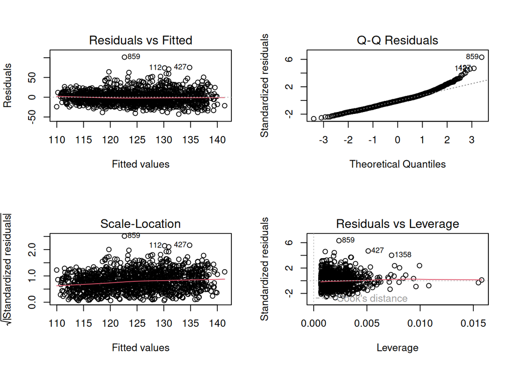

```r
par(mfrow = c(2,2))

plot(lm_age_waist)
```

### Wykresy dla wieku, wagi

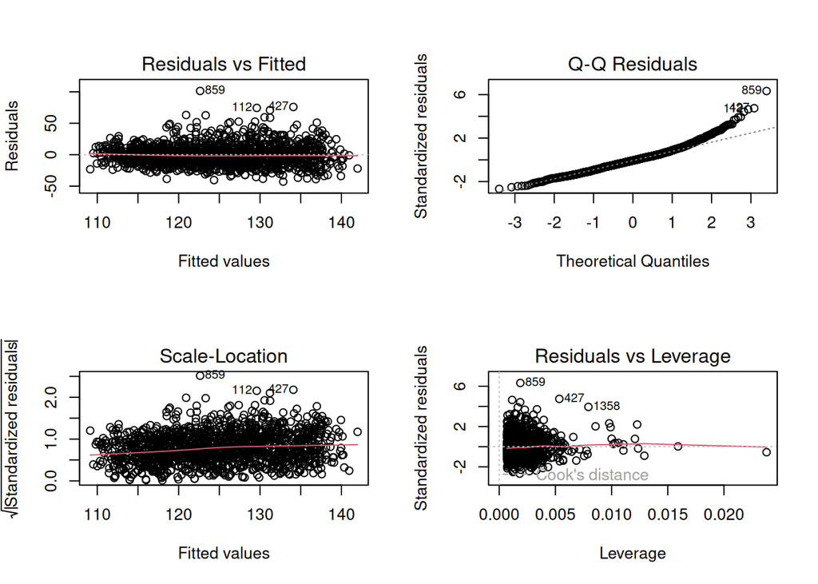

```r
par(mfrow = c(2,2))

plot(lm_age_weight)
```

**2. Wykres kwantyl - kwantyl:** Werifukuje normalność rozkładu reszt. Punkty leżą głównie wzdłuż lini referencyjnej, oprócz widocznego odstępu przy wyższych wartościach, które mogą zaburzać nam model.

**4. Reszty vs Wpływ obserwacji:** Identyfikuje obserwacje wpływowe (outliers, high-leverage points). Na naszym wykresie linia Cooka jest praktycznie niewidoczna - wskazuje na brak outlierów.

## Test modeli

Zrobimy testy modeli `(systolic~age+waist)` i `(systolic~age+weight)`. Za pomocą biblotek `lmtest, broom` wyświetlimy wyniki w formie tabeli. Jeżeli spełnią wymagania interpretacji testów poprawnych (p.value > 0.05) to wyświetlimy ‘OK’.

```r
library(lmtest)
library(broom)

# Tabela porównawcza
results_age_waist <- get_test_results(lm_age_waist)
results_age_weight <- get_test_results(lm_age_weight)

comparison_table <- data.frame(
  Test = results_age_waist$Test,
  lm_SO_Stat = round(results_age_waist$Statystyka, 3),
  lm_SO_p = round(results_age_waist$p_value, 4),
  lm_SO_log_Stat = round(results_age_weight$Statystyka, 3),
  lm_SO_log_p = round(results_age_weight$p_value, 4)
)

colnames(comparison_table) <- c("Test",
                                "Stat. (Age+Waist)", "p-value (Age+Waist)",
                                "Stat. (Age+Weight)", "p-value (Age+Weight)")

# Dodajemy znaczenie gwiazdkowe
comparison_table <- comparison_table %>%
  mutate(
    `Wniosek (Age+Waist)` = ifelse(`p-value (Age+Waist)` < 0.05, "Problem***", "OK"),
    `Wniosek (Age+Weight)` = ifelse(`p-value (Age+Weight)` < 0.05, "Problem***", "OK")
  )

knitr::kable(comparison_table, align = "c", caption = "Porównanie diagnostyki modeli")
```

Porównanie diagnostyki modeli

| Test | Stat. (Age+Waist) | p-value (Age+Waist) | Stat. (Age+Weight) | p-value (Age+Weight) | Wniosek (Age+Waist) | Wniosek (Age+Weight) |
| --- | --- | --- | --- | --- | --- | --- |
| Durbin-Watson (autokorelacja) | 2.047 | 0.8177 | 2.041 | 0.7830 | OK | OK |
| Breusch-Pagan (homoskedastyczność) | 30.220 | 0.0000 | 33.285 | 0.0000 | Problem*** | Problem*** |
| Shapiro-Wilk (normalność) | 0.967 | 0.0000 | 0.965 | 0.0000 | Problem*** | Problem*** |
| RESET (liniowość) | 1.582 | 0.2059 | 1.996 | 0.1362 | OK | OK |

Obydwa modele mają `p<00.1` przy teście na homoskedastyczność Breuscha-Pagana. Wykazuje to heroskedatyczność - wariancja reszt nie jest stała i predykcje będą mniej precyzyjne dla skrajnych wartości.

Kolejnym problemem jest nienormalność reszt przy teście Shapiro-Wilk. Wynika z niego, że rozkład błędów odbiega od normalności.

# Model regresji wielomianowy

Model wielomianowy opisuje zmienną objaśnianą za pomocą nieliniowej funkcji potęgowej zmiennej objaśniającej.

## Budowa i porównanie modeli

- `lm(systolic ~ age + I(age^2))` - Regresja wielomianowa zmiennej wieku.
- `lm(systolic ~ waist + I(waist^2)` - Regresja wielomianowa zmiennej obwodu talii.

```r
library(broom)
library(knitr)
library(kableExtra)

wielomian_age <- lm(systolic ~ age + I(age^2), data=health)
summary(wielomian_age)
```

```
##
## Call:
## lm(formula = systolic ~ age + I(age^2), data = health)
##
## Residuals:
##     Min      1Q  Median      3Q     Max
## -41.387  -9.852  -1.151   8.224  99.455
##
## Coefficients:
##              Estimate Std. Error t value Pr(>|t|)
## (Intercept) 1.093e+02  3.566e+00  30.658   <2e-16 ***
## age         1.924e-01  1.523e-01   1.263    0.207
## I(age^2)    2.243e-03  1.501e-03   1.494    0.135
## ---
## Signif. codes:  0 '***' 0.001 '**' 0.01 '*' 0.05 '.' 0.1 ' ' 1
##
## Residual standard error: 16.14 on 1472 degrees of freedom
## Multiple R-squared:  0.1626, Adjusted R-squared:  0.1615
## F-statistic:   143 on 2 and 1472 DF,  p-value: < 2.2e-16
```

```r
wielomian_waist <- lm(systolic ~ waist + I(waist^2), data=health)
summary(wielomian_waist)
```

```
##
## Call:
## lm(formula = systolic ~ waist + I(waist^2), data = health)
##
## Residuals:
##     Min      1Q  Median      3Q     Max
## -42.887 -11.424  -2.328   8.995 104.885
##
## Coefficients:
##              Estimate Std. Error t value Pr(>|t|)
## (Intercept) 87.223009  12.725171   6.854 1.05e-11 ***
## waist        0.558803   0.244652   2.284   0.0225 *
## I(waist^2)  -0.001791   0.001160  -1.545   0.1227
## ---
## Signif. codes:  0 '***' 0.001 '**' 0.01 '*' 0.05 '.' 0.1 ' ' 1
##
## Residual standard error: 17.37 on 1472 degrees of freedom
## Multiple R-squared:  0.02984,    Adjusted R-squared:  0.02852
## F-statistic: 22.64 on 2 and 1472 DF,  p-value: 2.073e-10
```

```r
# 3. Łączenie wyników
comparison_table <- bind_rows(
  create_metrics_row(wielomian_age, "Ciśnienie ~ Wiek + Wiek^2"),
  create_metrics_row(wielomian_waist, "Ciśnienie ~ Obwód talii + Obwód talii ^2")
) %>%
  select(Model, everything())

# 4. Formatowanie tabeli
comparison_table %>%
  kable(align = c("l", rep("c", ncol(.)-1)), caption = "Porównanie modeli") %>%
  kable_styling(
    bootstrap_options = c("striped", "hover"),
    full_width = FALSE,
    position = "center"
  ) %>%
  row_spec(0, bold = TRUE) %>%
  column_spec(1, bold = TRUE)
```

Porównanie modeli

| Model | R-squared | Adj. R-squared | Resid. SE | AIC | BIC | F-statistic | p-value | Observations | Missing |
| --- | --- | --- | --- | --- | --- | --- | --- | --- | --- |
| Ciśnienie ~ Wiek + Wiek^2 | 0.1626 | 0.1615 | 16.1351 | 12394.80 | 12415.99 | 142.9537 | 0 | 1475 | 0 |
| Ciśnienie ~ Obwód talii + Obwód talii ^2 | 0.0298 | 0.0285 | 17.3675 | 12611.93 | 12633.12 | 22.6379 | 0 | 1475 | 0 |

### Ciśnienie ~ Wiek + Wiek^2

- Wiek przestał być istotnie statystycznie w modelu wielomianowym (p = 0.207).
- Wielomian wieku wyjaśnia 16.26% zmienności ciśnienia (na bazie $R^2$).

### Ciśnienie ~ Obwód talii + Obwód talii^2

- Wyjaśniona wariancja (R²): Tylko 2.98%. Obwód talii ma bardzo słaby wpływ na ciśnienie krwi.
- Test F (p < 0.001): Mimo istotności statystycznej, praktyczna użyteczność modelu jest ograniczona.

### Wnioski

Oba modele wielomianowe mają słabe praktyczne zastosowanie (Test F p<0.001), dodatkowo wiek przestaje być istotnie statystyczny. Z uwagi na to ten model z tymi zmiennymi nie pasuje do przewidywania ciśnienia.

## Wzór modeli

1. $systolic = 109.3 + 0.1924 \cdot age + 0.0022 * age^2 + \epsilon$
2. $systolic = 87.223 + 0.5588 \cdot waist - 0.0017 \cdot waist^2 + \epsilon$

## Wykres reszt

### Wykresy dla wielomianu wieku

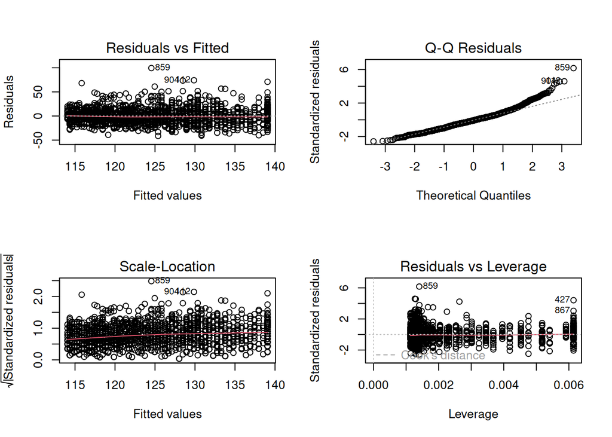

```r
par(mfrow = c(2,2))

plot(wielomian_age)
```

### Wykresy dla wielomianu obwodu talii

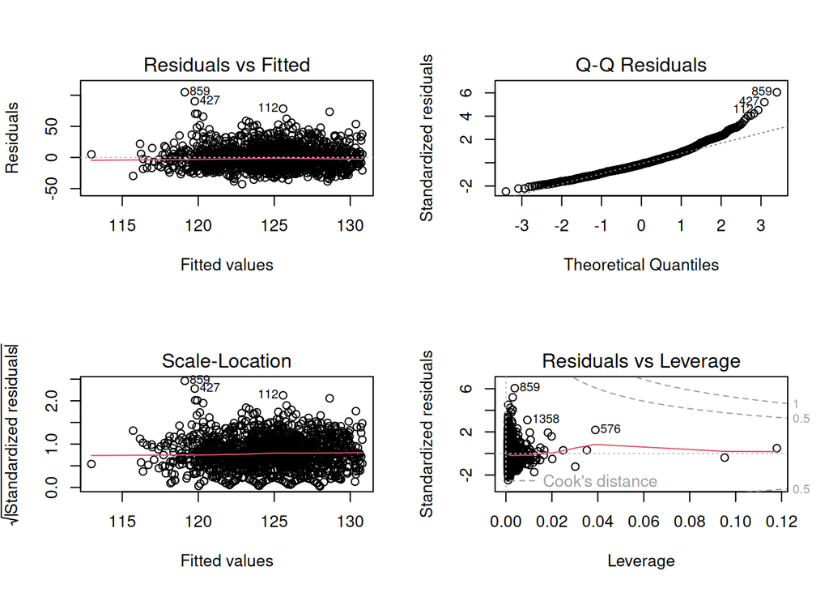

```r
par(mfrow = c(2,2))

plot(wielomian_waist)
```

**1. Reszty vs Wartości dopasowane:** wykres sprawdza liniowość związku i stałą wariancję reszt. U nas punkty nie tworzą wzoru (brak np. krzywej lub lejku) - sugeruje to liniowość i homoskedatyczność modelu.

## Test modeli

Zrobimy testy modeli `(systolic~age+age^2)` i `(systolic~waist+waist^2)`. Za pomocą biblotek `lmtest, broom` wyświetlimy wyniki w formie tabeli. Jeżeli spełnią wymagania interpretacji testów poprawnych (p.value > 0.05) to wyświetlimy ‘OK’.

```r
library(lmtest)
library(broom)

# Tabela porównawcza
results_age <- get_test_results(wielomian_age)
results_waist <- get_test_results(wielomian_waist)

comparison_table <- data.frame(
  Test = results_age$Test,
  lm_SO_Stat = round(results_age$Statystyka, 3),
  lm_SO_p = round(results_age$p_value, 4),
  lm_SO_log_Stat = round(results_waist$Statystyka, 3),
  lm_SO_log_p = round(results_waist$p_value, 4)
)

colnames(comparison_table) <- c("Test",
                                "Stat. (Age^2)", "p-value (Age^2)",
                                "Stat. (Waist^2)", "p-value (Waist^2)")

# Dodajemy znaczenie gwiazdkowe
comparison_table <- comparison_table %>%
  mutate(
    `Wniosek (Age^2)` = ifelse(`p-value (Age^2)` < 0.05, "Problem***", "OK"),
    `Wniosek (Waist^2)` = ifelse(`p-value (Waist^2)` < 0.05, "Problem***", "OK")
  )

knitr::kable(comparison_table, align = "c", caption = "Porównanie diagnostyki modeli")
```

Porównanie diagnostyki modeli

| Test | Stat. (Age^2) | p-value (Age^2) | Stat. (Waist^2) | p-value (Waist^2) | Wniosek (Age^2) | Wniosek (Waist^2) |
| --- | --- | --- | --- | --- | --- | --- |
| Durbin-Watson (autokorelacja) | 2.050 | 0.8335 | 2.060 | 0.8746 | OK | OK |
| Breusch-Pagan (homoskedastyczność) | 28.249 | 0.0000 | 1.259 | 0.5328 | Problem*** | OK |
| Shapiro-Wilk (normalność) | 0.967 | 0.0000 | 0.955 | 0.0000 | Problem*** | Problem*** |
| RESET (liniowość) | 0.882 | 0.4143 | 0.826 | 0.4380 | OK | OK |

Model wielomianu dla wieku ma problemy z homoskedatycznością w teście Breusch-Pagan, wariancja reszt nie jest stała, mogą wystąpić problemy przy predykcji dla skrajnych wartości. Istnieje również problem z normalnością w teście Shapiro-Wilk, co było już widoczne w wykresie kwantylowym.

Natomiast wielomian obwodu talii ma jedynie widoczny problem z normalnością.

# Model regresji ze zmnienną binarną (0-1)

W naszym modelu istnieją dwie zmienne binarne: smoker i diabetes, kolejno palacz i cukrzyca. Wskazują one, czy nasz pacjent pali (Tak/Nie) lub czy ma cukrzyce (Tak/Nie).

## Budowa i porównanie modeli

- `lm(systolic ~ smoker)` - Regresja zmiennej binarnej, wyjaśnienie ciśnienia ze względu na palenie papierosów przez pacjenta
- `lm(systolic ~ diabetes)` - Regresja zmiennej binarnej, wyjaśnienie ciśnienia ze względu na cukrzycę

```r
library(broom)
library(knitr)
library(kableExtra)

lm_smoker <- lm(systolic ~ smoker, data=health)
summary(lm_smoker)
```

```
##
## Call:
## lm(formula = systolic ~ smoker, data = health)
##
## Residuals:
##     Min      1Q  Median      3Q     Max
## -42.847 -12.417  -2.417   9.153 101.583
##
## Coefficients:
##             Estimate Std. Error t value Pr(>|t|)
## (Intercept) 126.8468     0.6302  201.28  < 2e-16 ***
## smoker       -4.4297     0.9115   -4.86  1.3e-06 ***
## ---
## Signif. codes:  0 '***' 0.001 '**' 0.01 '*' 0.05 '.' 0.1 ' ' 1
##
## Residual standard error: 17.49 on 1473 degrees of freedom
## Multiple R-squared:  0.01578,    Adjusted R-squared:  0.01511
## F-statistic: 23.62 on 1 and 1473 DF,  p-value: 1.301e-06
```

```r
lm_diabetes <- lm(systolic ~ diabetes, data=health)
summary(lm_diabetes)
```

```
##
## Call:
## lm(formula = systolic ~ diabetes, data = health)
##
## Residuals:
##     Min      1Q  Median      3Q     Max
## -43.625 -11.625  -1.625   8.619 100.375
##
## Coefficients:
##             Estimate Std. Error t value Pr(>|t|)
## (Intercept) 123.6253     0.4897 252.457  < 2e-16 ***
## diabetes      7.7557     1.2978   5.976 2.86e-09 ***
## ---
## Signif. codes:  0 '***' 0.001 '**' 0.01 '*' 0.05 '.' 0.1 ' ' 1
##
## Residual standard error: 17.42 on 1473 degrees of freedom
## Multiple R-squared:  0.02367,    Adjusted R-squared:  0.02301
## F-statistic: 35.71 on 1 and 1473 DF,  p-value: 2.863e-09
```

```r
# 3. Łączenie wyników
comparison_table <- bind_rows(
  create_metrics_row(lm_smoker, "Ciśnienie ~ Palacz"),
  create_metrics_row(lm_diabetes, "Ciśnienie ~ Cukrzyca")
) %>%
  select(Model, everything())

# 4. Formatowanie tabeli
comparison_table %>%
  kable(align = c("l", rep("c", ncol(.)-1)), caption = "Porównanie modeli") %>%
  kable_styling(
    bootstrap_options = c("striped", "hover"),
    full_width = FALSE,
    position = "center"
  ) %>%
  row_spec(0, bold = TRUE) %>%
  column_spec(1, bold = TRUE)
```

Porównanie modeli

| Model | R-squared | Adj. R-squared | Resid. SE | AIC | BIC | F-statistic | p-value | Observations | Missing |
| --- | --- | --- | --- | --- | --- | --- | --- | --- | --- |
| Ciśnienie ~ Palacz | 0.0158 | 0.0151 | 17.4869 | 12631.16 | 12647.05 | 23.6165 | 0 | 1475 | 0 |
| Ciśnienie ~ Cukrzyca | 0.0237 | 0.0230 | 17.4167 | 12619.28 | 12635.17 | 35.7127 | 0 | 1475 | 0 |

### Ciśnienie ~ Palacz

- Palenie papierosów jest według tego modelu statestycznie istotne (p<0.01). Natomiast sugeruje, że palenie papierosów obniża ciśnienie o ~4.43 jednostki.
- Palenie papierosów wyjaśnia natomiast jedynie 1.58% zmienności ciśnienia - praktycznie nieistniejący wpływ pod względem modelowania.

### Ciśnienie ~ Cukrzyca

- Cukrzyca jest statystycznie istotne dla tego modelu (p<0.01), jeśli pacjent ma cukrzycę to podwyższa się średnio jego ciśnienie o 7.756 jednostki.
- Sama cukrzyca wyjaśnia jedynie 2.37% ciśnienia. Jest to praktycznie niewystarczające by na jej bazie przeprowadzać predykcje.

### Wnioski

Oba modele mają nieznaczny wpływ na predykcje ciśnienia skurczowego. Wynika z tego, że samodzielnie nie są w stanie wyjaśnić tej zmiennej objaśnianej do realistycznego modelu predykcji potrzebne by były dodatkowe zmienne.

## Wzór modeli

1. $systolic = 126.85 - 4.43 \cdot smoker + \epsilon$
2. $systolic = 123.62 + 7.758 \cdot diabetes + \epsilon$

## Wykres reszt

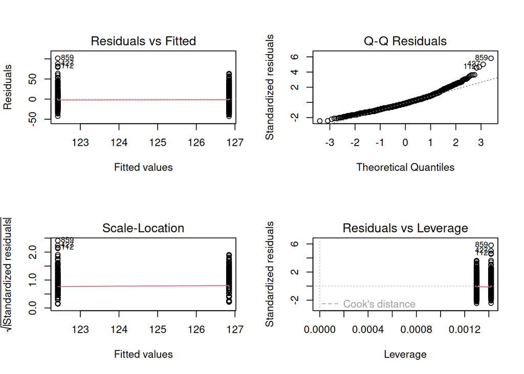

```r
par(mfrow = c(2,2))

plot(lm_smoker)
```

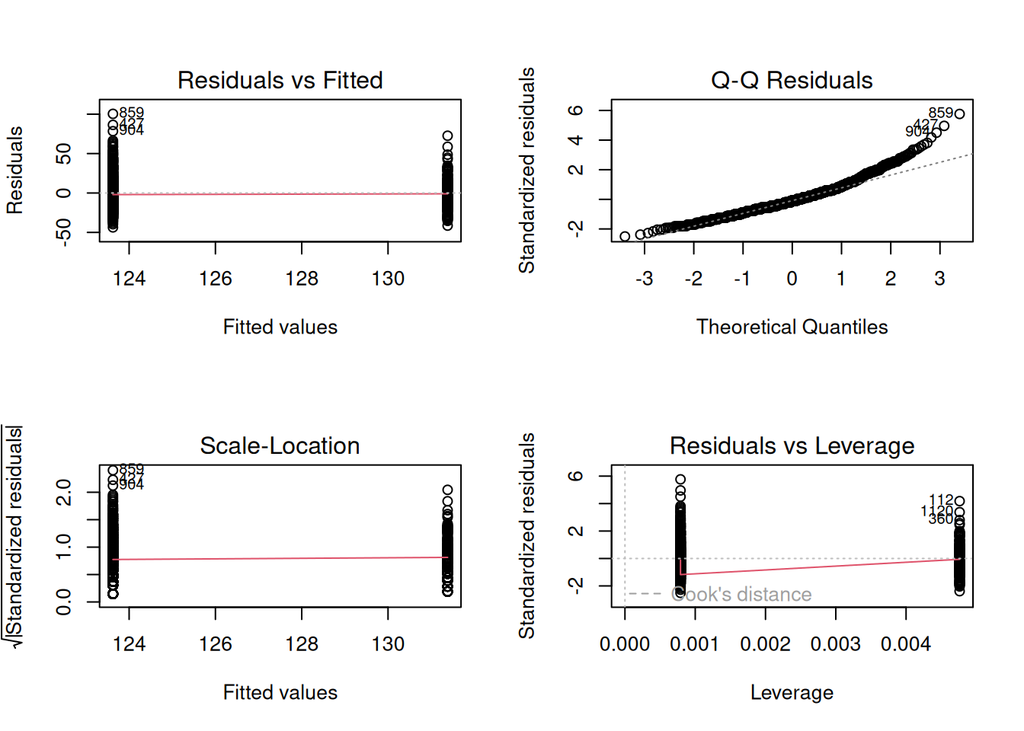

```r
par(mfrow = c(2,2))

plot(lm_diabetes)
```

Z uwagi na istotę binarną tych zmiennych większość wykresów nie pokazuje nam przydatnych danych do analizy poprawności tych modeli.

## Test modeli

Zrobimy testy modeli `(systolic~smoker)` i `(systolic~diabetes)`. Za pomocą biblotek `lmtest, broom` wyświetlimy wyniki w formie tabeli. Jeżeli spełnią wymagania interpretacji testów poprawnych (p.value > 0.05) to wyświetlimy ‘OK’.

```r
# Tabela porównawcza
results_smoker <- get_test_results(lm_smoker)
results_diabetes <- get_test_results(lm_diabetes)

comparison_table <- data.frame(
  Test = results_smoker$Test,
  lm_SO_Stat = round(results_smoker$Statystyka, 3),
  lm_SO_p = round(results_smoker$p_value, 4),
  lm_SO_log_Stat = round(results_smoker$Statystyka, 3),
  lm_SO_log_p = round(results_smoker$p_value, 4)
)

colnames(comparison_table) <- c("Test",
                                "Stat. (Smoker)", "p-value (Smoker)",
                                "Stat. (Diabetes)", "p-value (Diabetes)")

# Dodajemy znaczenie gwiazdkowe
comparison_table <- comparison_table %>%
  mutate(
    `Wniosek (Smoker)` = ifelse(`p-value (Smoker)` < 0.05, "Problem***", "OK"),
    `Wniosek (Diabetes)` = ifelse(`p-value (Diabetes)` < 0.05, "Problem***", "OK")
  )

knitr::kable(comparison_table, align = "c", caption = "Porównanie diagnostyki modeli")
```

Porównanie diagnostyki modeli

[output not shown]